| title: “BST260 - Final project” |
| --- |
| author: “” |
| date: “12/15/2022” |
| output: |
| html_document: |
| df_print: paged |
| header-includes: |

# Introduction

The dataset that I will analyze was assembled by Korean investigators for a cross-sectional retrospective research study aiming to evaluate accuracy of triage in the emergency department by the Korean Triage and Acuity Scale. The original study report was published in 2019 (1) and the dataset was made available on kaggle.com. This is a tidy dataset including 1267 records of adult patients who were admitted to the emergency department (ED) at two different hospitals between October 2016 and September 2017. It includes a variable detailing the disposition of each patient upon discharge from the ED. My initial plan to predict emergency surgery aiming to identify patients who may require emergency surgery early in order to reduce the time until start of the surgical procedure. However, there were only 22 patients (1.7%) who required emergency surgery upon exploratory analysis (Fig. 1). Accordingly, the aim of this project was adapted to predict inpatient admission (including mortality, or transfer to another hospital) in contrast to discharge home. The ability to predict hospital admission of ED patients may help guide and refine the triage process.

To predict inpatient admission, I will compare two approaches:

- **Clinical approach**: candidate predictors will be pre-selected based on clinical reasoning, then a stepwise forward selection using AIC will be used to build and train a logistic regression model
- **Machine learning approach**: using a random forest model (as many perdictors will be included)

Internal split will be used to derive a training (80% of observations) and a validation set (20%). The training set will be used to fit both models For the clinical model, model calibration will be assessed using a calibration plot comparing predicted risk and observed rates across deciles of predicted inpatient admission risk. To chose a cutoff for the binary prediction, sensitivity and specificity for different cutoffs of predicted inpatient risk will be evaluated.  
Finally, performance of both models will be compared in the validation set using overall accuracy, sensitivity, and specificity.

# Results

All cases with any missing values for potential predictors were removed and a total of 1228 cases remained in the complete case cohort of which 418 (34%) were admitted. This cohort was split into a training dataset (n=982) and a validation set (n=246). Characteristics of the complete case cohort by outcome status are summarized in Table 1 below.

The following predictors were pre-selected for the **clinical model**: sex, age, pain rating on numeric rating scale (0-10), triage rating by the nurse upon arrival, mode of arrival, if the patient had an injury, if the patient was in shock upon arrival (heart rate > systolic blood pressure), mental status and if the patient was hyperventilating and had fever upon arrival. Performing stepwise forward selection and logistic regression, the final model included triage rating (KTAS_RN), age, mode of arrival (2=ambulance, 3=private vehicle, 4= other, vs. 1=walking), fever (hypertherm), injury and shock and is summarized below.

```
##
## Call:
## glm(formula = admission ~ KTAS_RN + Age + as.factor(arrival) +
##     hypertherm + injury + shock, family = "binomial", data = ED.train)
##
## Deviance Residuals:
##     Min       1Q   Median       3Q      Max
## -2.0372  -0.8024  -0.4765   0.9187   2.4467
##
## Coefficients:
##                      Estimate Std. Error z value Pr(>|z|)
## (Intercept)         -0.084733   0.564747  -0.150  0.88074
## KTAS_RN             -0.768416   0.102214  -7.518 5.57e-14 ***
## Age                  0.018588   0.004219   4.406 1.05e-05 ***
## as.factor(arrival)2  1.299313   0.397141   3.272  0.00107 **
## as.factor(arrival)3  0.557638   0.389871   1.430  0.15263
## as.factor(arrival)4 -0.260732   0.878573  -0.297  0.76664
## hypertherm           1.055091   0.339566   3.107  0.00189 **
## injury              -0.668763   0.242537  -2.757  0.00583 **
## shock                0.845204   0.389749   2.169  0.03011 *
## ---
## Signif. codes:  0 '***' 0.001 '**' 0.01 '*' 0.05 '.' 0.1 ' ' 1
##
## (Dispersion parameter for binomial family taken to be 1)
##
##     Null deviance: 1229.3  on 981  degrees of freedom
## Residual deviance: 1014.8  on 973  degrees of freedom
## AIC: 1032.8
##
## Number of Fisher Scoring iterations: 4
```

Cutoffs of predicted inpatient risk ranging from 0.3 to 0.8 were evaluated in regards to sensitivity and specificity for correctly classifying inpatient admission from the ED (Table 2). A cutoff with a good balance between sensitivity and specificity with a slight emphasis on high sensitivity (low false negative rate) was preferred in order to identify patients who might be more likely to require inpatient admission. A predicted risk cutoff of 0.3 was chosen.

The **machine learning model** was fitted using random forest. The minimum node size was tuned and chosen based on accuracy in the training set. Figure 4 below shows the accuracy for different node sizes.

Table 3 and 4 show the confusion matrix stratified by predicted vs. observed inpatient admission in the validation set based on the clinical (Table 3) and random forest model (Table 4).

Accuracy, sensitivity and specificity for both models are summarized in Table 5. Overall accuracy is comparable for both models. While the random forest model achieves a very high specificity (91%), the sensitivity and balance between sensitivity and specificity is much better for the clinical compared to the machine learning model.

# Conclusion

Both approaches, predictor selection based on clinical reasoning combined with stepwise logistic regression as well as random forest, produced models with overall good accuracy. The sensitivity and specificity differed for both models. In conclusion, of the two models I would prefer the clinical model in order to predict inpatient admission of patients in the ED. I was able to chose a risk cutoff for this model according to my performance preferences for this setting (higher sensitivity more important than good specificity and some balance between both metrics). Also, the clinical model allows healthcare providers in the ED to identify and pay more attention to the most important predictors.

Performance of the machine learning model could potentially be improved with choice of a different machine learning approach and fine tuning of modifiable parameters. The free text variables “chief complaint” and “ED diagnosis” contain important information. Extraction of this information and integration in the models would most likely enhance the predictive ability of both models.

# References

Data source: https://www.kaggle.com/datasets/ilkeryildiz/emergency-service-triage-application

1. Original analysis: https://journals.plos.org/plosone/article?id=10.1371/journal.pone.0216972

# Appendix

## Figures

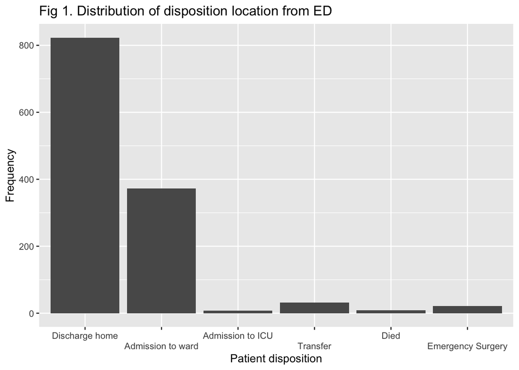

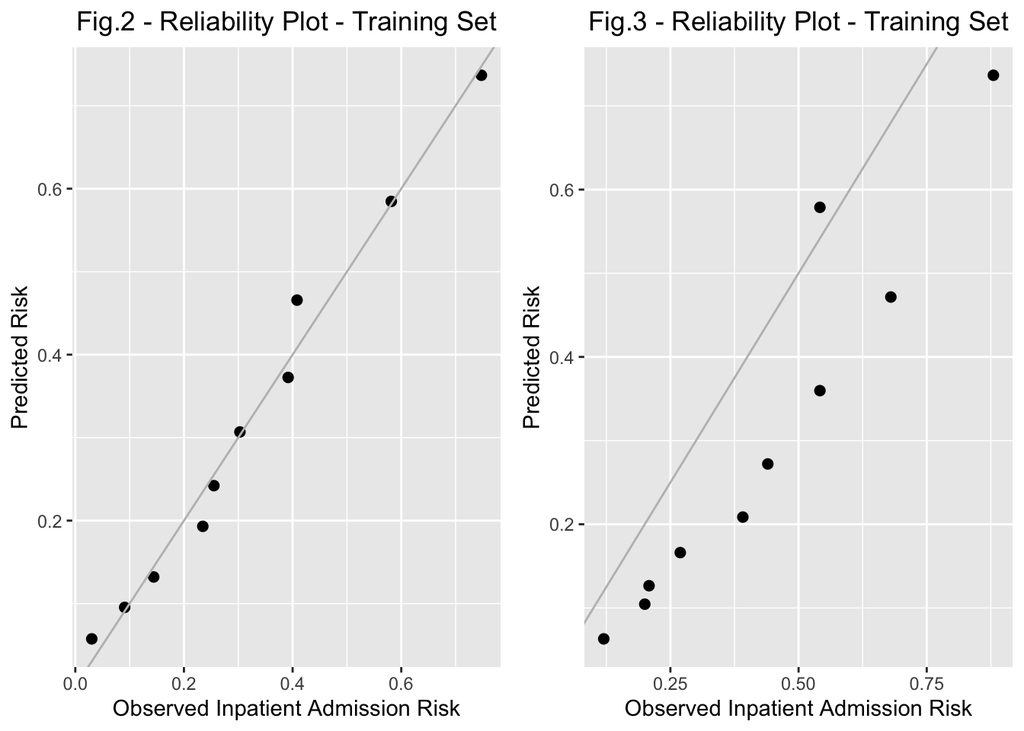

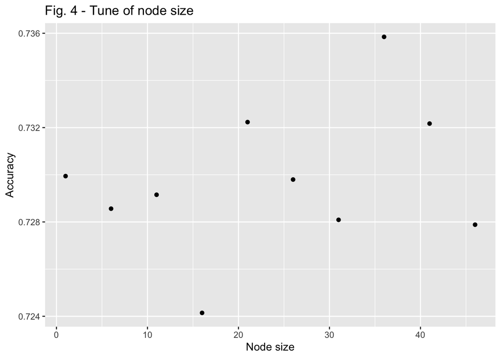

## Tables

Patient characteristics by discharge disposition

|  | Inpatient admission (N=418) | Discharge home (N=810) | Total (N=1228) |
| --- | --- | --- | --- |
| Sex |  |  |  |
| Female | 187 (44.7%) | 400 (49.4%) | 587 (47.8%) |
| Male | 231 (55.3%) | 410 (50.6%) | 641 (52.2%) |
| Age |  |  |  |
| Mean (SD) | 60.6 (18.3) | 50.7 (19.7) | 54.1 (19.8) |
| Median [Min, Max] | 64.0 [16.0, 96.0] | 51.5 [16.0, 95.0] | 56.0 [16.0, 96.0] |
| Pain rating (0-10) |  |  |  |
| Mean (SD) | 2.00 (2.28) | 2.53 (2.29) | 2.35 (2.30) |
| Median [Min, Max] | 0 [0, 10.0] | 3.00 [0, 10.0] | 3.00 [0, 10.0] |
| Triage |  |  |  |
| Resuscitation | 6 (1.4%) | 0 (0%) | 6 (0.5%) |
| Emergent | 123 (29.4%) | 73 (9.0%) | 196 (16.0%) |
| Urgent | 184 (44.0%) | 260 (32.1%) | 444 (36.2%) |
| Less urgent | 97 (23.2%) | 402 (49.6%) | 499 (40.6%) |
| Non-urgent | 8 (1.9%) | 75 (9.3%) | 83 (6.8%) |
| Shock (HR/SBP > 1) |  |  |  |
| Shock | 24 (5.7%) | 15 (1.9%) | 39 (3.2%) |
| No | 394 (94.3%) | 795 (98.1%) | 1189 (96.8%) |
| Hyperventilation (Respiratory rate > 25/min) |  |  |  |
| Hyperventilation | 10 (2.4%) | 5 (0.6%) | 15 (1.2%) |
| No | 408 (97.6%) | 805 (99.4%) | 1213 (98.8%) |
| Fever (Temp > 37.5) |  |  |  |
| Fever | 33 (7.9%) | 26 (3.2%) | 59 (4.8%) |
| No | 385 (92.1%) | 784 (96.8%) | 1169 (95.2%) |
| Mode of arrival |  |  |  |
| Walking | 16 (3.8%) | 63 (7.8%) | 79 (6.4%) |
| Ambulance | 208 (49.8%) | 185 (22.8%) | 393 (32.0%) |
| Private vehicle | 191 (45.7%) | 551 (68.0%) | 742 (60.4%) |
| other | 3 (0.7%) | 11 (1.4%) | 14 (1.1%) |
| Injured |  |  |  |
| Injured | 42 (10.0%) | 193 (23.8%) | 235 (19.1%) |
| No injury | 376 (90.0%) | 617 (76.2%) | 993 (80.9%) |
| Mental status |  |  |  |
| Alert | 388 (92.8%) | 781 (96.4%) | 1169 (95.2%) |
| Verbal response | 19 (4.5%) | 18 (2.2%) | 37 (3.0%) |
| Pain response | 9 (2.2%) | 11 (1.4%) | 20 (1.6%) |
| Unresponsive | 2 (0.5%) | 0 (0%) | 2 (0.2%) |

Different cutoffs of predicted inpatient admission risk

|  | Sensitivity | Specificity | Accuracy |
| --- | --- | --- | --- |
| 0.3 | 0.7316294 | 0.6651719 | 0.6863544 |
| 0.4 | 0.5495208 | 0.8086697 | 0.7260692 |
| 0.5 | 0.4472843 | 0.8804185 | 0.7423625 |
| 0.6 | 0.2939297 | 0.9431988 | 0.7362525 |
| 0.7 | 0.1757188 | 0.9745889 | 0.7199593 |
| 0.8 | 0.0319489 | 0.9970105 | 0.6894094 |

Clinical model

|  | Discharge home | Inpatient admission |
| --- | --- | --- |
| predicted discharge | 104 | 39 |
| predicted admission | 37 | 66 |

Random forest model

|  | Discharge home | Inpatient admission |
| --- | --- | --- |
| predicted discharge | 129 | 62 |
| predicted admission | 12 | 43 |

Performance of both models in validation set

|  | Clinical model | Random forest |
| --- | --- | --- |
| Specificity | 0.7375887 | 0.9148936 |
| Sensitivity | 0.6285714 | 0.4095238 |
| Accuracy | 0.6910569 | 0.6991870 |

## Code

```r
#read in data
library(readr)
emergency <- read_delim("~/Library/Mobile Documents/com~apple~CloudDocs/Fall2/BST260/emergency.csv",
   delim = ";", escape_double = FALSE, trim_ws = TRUE)
#data exploration
library(dplyr)
library(ggplot2)
# outcome
## Disposition: 1 = Discharge, 2 = Admission to ward, 3 = Admission to ICU, 4 = Discharge, 5 = Transfer, 6 = Death, 7 = Surgery
emergency$Disposition <- as.factor(ifelse(emergency$Disposition == 1 | emergency$Disposition == 4, 1, emergency$Disposition))

#hist and provide histogram
label <- c("Discharge home", "Admission to ward", "Admission to ICU", "Transfer", "Died", "Emergency Surgery")
emergency$disposition <- factor(emergency$Disposition, levels = c(1, 2, 3, 5, 6, 7), labels = label)
#emergency |> ggplot() + geom_bar(aes(disposition)) + xlab("Patient disposition") + ylab("Frequency") + ggtitle("Fig 1. Distribution of disposition location from ED") + scale_x_discrete(guide = guide_axis(n.dodge=2))
# binary outcome: discharge - disposition 1 of 4
emergency$admission <- ifelse(emergency$Disposition == 1 | emergency$Disposition == 4, 0, 1)
##data cleaning

# use as is
## sex: 1 female, 2 male
## age: continuous in years
## mental: 1 = Alert, 2 = Verbal Response, 3 = Pain Response, 4 = Unresponsive
## chief complaint: text
## pain: yes=1, no = 0
## SBP: systolic blood pressure
## DBP: diastolic blood pressure
## HR: heart rate
## KTAS_RN: 1 = resuscitation, 2 = emergent, 3 = urgent, 4 = less urgent, 5 = non-urgent

# delete
## group, which hospital; patients number per hour; saturation - many missing, and available values range from 90 to 100, not very pathologic, no high predictive value to be expected
emergency <- emergency |> select(-Group, -`Patients number per hour`, -Saturation, -KTAS_expert, -Error_group, -mistriage, -`KTAS duration_min`)

#clean/rename
emergency$sbp <- as.numeric(emergency$SBP)
emergency$dbp <- as.numeric(emergency$DBP)
emergency$hr <- as.numeric(emergency$HR)
emergency$resp <- as.numeric(emergency$RR)
emergency$temp <- as.numeric(emergency$BT)
emergency <- emergency |> select(-SBP, -DBP, -HR, -RR, -BT)

# recategorize
##arrival mode: 1 = Walking, 2 = Public Ambulance, 3 = Private Vehicle, 4 = Private Ambulance, 5,6,7 = Other]
## -> 1 = walking, 2 = ambulance, 3 = private vehicle, 4 = other
emergency$arrival <- ifelse(emergency$`Arrival mode`==2 | emergency$`Arrival mode`==4, 2, emergency$`Arrival mode`)
emergency$arrival <- ifelse(emergency$arrival==5 | emergency$arrival==6 | emergency$arrival==7, 4, emergency$arrival)
## injury: 2=yes, 1=no -> 1 yes, 0 no
emergency$injury <- ifelse(emergency$Injury==2, 1, 0)
emergency <- emergency |> select(-Injury, -`Arrival mode`)
##NRS_pain: replace missing as 0, if they did not have pain
emergency$NRS_pain <-  as.numeric(emergency$NRS_pain)
emergency$NRS_pain <-  ifelse(is.na(emergency$NRS_pain) & emergency$Pain==0, 0, emergency$NRS_pain)

# generate additional variables out of existing predictors:
## shock index: HR/SBP
emergency$shock_index <- emergency$hr/emergency$sbp
## shock: shock index > 1
emergency$shock <- ifelse(emergency$shock_index > 1, 1, 0)
## hyperventilation: respiratory rate > 25
emergency$hyperventilation <- ifelse(emergency$resp > 25, 1, 0)
## fever based on body temperature?
emergency$hypertherm <- ifelse(emergency$temp > 37.5 & !is.na(emergency$temp), 1, 0)

#fix some column_names
emergency$ED_diagnosis <- emergency$`Diagnosis in ED`
emergency$ED_LOS_min <- emergency$`Length of stay_min`
emergency$chief_complaint <- emergency$Chief_complain
emergency$mental_status <- emergency$Mental
emergency$pain_yn <- emergency$Pain
emergency <- emergency |> select(-`Diagnosis in ED`, -`Length of stay_min`, -Chief_complain, -Mental, -Pain)

## create a complete case cohort -> drop anyone with any missings as all variables kept in the dataset will be used for machine learning approach
ED_complete <- na.omit(emergency)
#creating a validation set with 20% of data
smp_size <- floor(0.80 * nrow(ED_complete))

## set the seed
set.seed(2404)
train_ind <- sample(seq_len(nrow(ED_complete)), size = smp_size)

ED.train <- ED_complete[train_ind, ]
ED.test <- ED_complete[-train_ind, ]

#create a table displaying characteristics by outcome including the preselected variables
library(table1)

ED_complete_table <- ED_complete

ED_complete_table$admission <-
  factor(ED_complete_table$admission, levels=c(1,0), labels=c("Inpatient admission", "Discharge home"))
ED_complete_table$KTAS_RN <-
  factor(ED_complete_table$KTAS_RN, levels=c(1,2,3,4,5), labels=c("Resuscitation", "Emergent", "Urgent", "Less urgent", "Non-urgent"))
ED_complete_table$Sex <-
  factor(ED_complete_table$Sex, levels=c(1,2), labels=c("Female", "Male"))
ED_complete_table$shock <-
  factor(ED_complete_table$shock, levels=c(1,0), labels=c("Shock", "No"))
ED_complete_table$hyperventilation <-
  factor(ED_complete_table$hyperventilation, levels=c(1,0), labels=c("Hyperventilation", "No"))
ED_complete_table$hypertherm <-
  factor(ED_complete_table$hypertherm, levels=c(1,0), labels=c("Fever", "No"))
ED_complete_table$injury <-
  factor(ED_complete_table$injury, levels=c(1,0), labels=c("Injured", "No injury"))
ED_complete_table$arrival <-
  factor(ED_complete_table$arrival, levels=c(1,2,3,4), labels=c("Walking", "Ambulance", "Private vehicle", "other"))
ED_complete_table$mental_status <-
  factor(ED_complete_table$mental_status, levels=c(1, 2, 3, 4), labels=c("Alert", "Verbal response", "Pain response", "Unresponsive"))

label(ED_complete_table$NRS_pain)       <- "Pain rating (0-10)"
label(ED_complete_table$KTAS_RN)       <- "Triage"
label(ED_complete_table$sbp)       <- "Systolic blood pressure, mmHg"
label(ED_complete_table$dbp)     <- "Diastolic blood pressure, mmHg"
label(ED_complete_table$shock_index) <- "Shock index"
label(ED_complete_table$shock) <- "Shock (HR/SBP > 1)"
label(ED_complete_table$hr) <- "Heart rate, bpm"
label(ED_complete_table$resp) <- "Respiratory rate (RR), per minute"
label(ED_complete_table$hyperventilation) <- "Hyperventilation (Respiratory rate > 25/min)"
label(ED_complete_table$temp) <- "Body tmeperature, celsius"
label(ED_complete_table$hypertherm) <- "Fever (Temp > 37.5)"
label(ED_complete_table$arrival) <- "Mode of arrival"
label(ED_complete_table$injury) <- "Injured"
label(ED_complete_table$mental_status) <- "Mental status"

#table1(~ Sex + Age + NRS_pain + KTAS_RN + shock + hyperventilation + hypertherm + arrival + injury + mental_status | admission, data=ED_complete_table, overall="Total", caption="Patient characteristics by discharge disposition")
#training the clinician model: sex, age, NRS_pain, KTAS_RN, arrival, injury, shock, hyperventilation, mental status, hyperthermia/fever
library(caret)

#stepwise forward regression with AIC as criterion
library(MASS)
Fitall.tr <- glm(admission ~ as.factor(Sex) + Age + NRS_pain + KTAS_RN + as.factor(arrival) + injury + shock + hyperventilation + as.factor(mental_status) + hypertherm, family="binomial", data= ED.train)
Fitstart <- glm(admission ~ 1, family="binomial", data= ED.train)
set.seed(2024)
m_clin <- step(Fitstart, scope=formula(Fitall.tr), direction="forward", k=2, trace=0)
summary(m_clin)
```

```
##
## Call:
## glm(formula = admission ~ KTAS_RN + Age + as.factor(arrival) +
##     hypertherm + injury + shock, family = "binomial", data = ED.train)
##
## Deviance Residuals:
##     Min       1Q   Median       3Q      Max
## -2.0372  -0.8024  -0.4765   0.9187   2.4467
##
## Coefficients:
##                      Estimate Std. Error z value Pr(>|z|)
## (Intercept)         -0.084733   0.564747  -0.150  0.88074
## KTAS_RN             -0.768416   0.102214  -7.518 5.57e-14 ***
## Age                  0.018588   0.004219   4.406 1.05e-05 ***
## as.factor(arrival)2  1.299313   0.397141   3.272  0.00107 **
## as.factor(arrival)3  0.557638   0.389871   1.430  0.15263
## as.factor(arrival)4 -0.260732   0.878573  -0.297  0.76664
## hypertherm           1.055091   0.339566   3.107  0.00189 **
## injury              -0.668763   0.242537  -2.757  0.00583 **
## shock                0.845204   0.389749   2.169  0.03011 *
## ---
## Signif. codes:  0 '***' 0.001 '**' 0.01 '*' 0.05 '.' 0.1 ' ' 1
##
## (Dispersion parameter for binomial family taken to be 1)
##
##     Null deviance: 1229.3  on 981  degrees of freedom
## Residual deviance: 1014.8  on 973  degrees of freedom
## AIC: 1032.8
##
## Number of Fisher Scoring iterations: 4
```

```r
#apply to validation set
ED.train$phat_clin <- predict(m_clin, type="response", newdata=ED.train)
ED.test$phat_clin <- predict(m_clin, type="response", newdata=ED.test)

#Calibration Plot -training set
##create risk deciles on predicted risk
cuts <- quantile(ED.train$phat_clin, prob=c(.1,.2,.3,.4,.5,.6,.7,.8,.9), na.rm=T)
ED.train$risk_decile <-cut(ED.train$phat_clin, breaks=c(0, cuts, 1))
dec<-c(1:10) #for plot
#observed proportion of difficult hearing in risk deciles
t1.train<-table(ED.train$risk_decile, ED.train$admission)
#addmargins(t1.train)
t2.train <- prop.table(t1.train, 1)
obs.train <- t2.train[,2] #for plot
#mean predicted risk in risk deciles
deciles.train <- ED.train %>% group_by(risk_decile) %>% summarise(mean=mean(phat_clin))
pred.train <- deciles.train$mean #for plot
cali_train<-data.frame(dec, obs.train, pred.train) # for plot
p1 <- ggplot(cali_train, aes(x=obs.train, y=pred.train)) + geom_point(size=2) + xlab("Observed Inpatient Admission Risk") + ylab("Predicted Risk") + ggtitle("Fig.2 - Reliability Plot - Training Set") + theme(plot.title = element_text(hjust = 0.5)) + geom_abline(intercept = 0, slope = 1, color="grey")

#Calibration Plot -validation set
##create risk deciles on predicted risk
cuts <- quantile(ED.test$phat_clin, prob=c(.1,.2,.3,.4,.5,.6,.7,.8,.9), na.rm=T)
ED.test$risk_decile <-cut(ED.test$phat_clin, breaks=c(0, cuts, 1))
dec<-c(1:10) #for plot
#observed proportion of difficult hearing in risk deciles
t1.test<-table(ED.test$risk_decile, ED.test$admission)
#addmargins(t1.test)
t2.test <- prop.table(t1.test, 1)
obs.test <- t2.test[,2] #for plot
#mean predicted risk in risk deciles
deciles.test <- ED.test %>% group_by(risk_decile) %>% summarise(mean=mean(phat_clin))
pred.test <- deciles.test$mean #for plot
cali_test<-data.frame(dec, obs.test, pred.test) # for plot
p2 <- ggplot(cali_test, aes(x=obs.test, y=pred.test)) + geom_point(size=2) + xlab("Observed Inpatient Admission Risk") + ylab("Predicted Risk") + ggtitle("Fig.3 - Reliability Plot - Training Set") + theme(plot.title = element_text(hjust = 0.5)) + geom_abline(intercept = 0, slope = 1, color="grey")
#check sensitivity and specificity for different cutoffs of predicted risk in training set
ED.train$admission <- as.factor(ED.train$admission)
## 0.3
ED.train$yhat_clin03 <- as.factor(ifelse(ED.train$phat_clin > 0.3, 1, 0))
cm_clinical_train03 <- confusionMatrix(ED.train$yhat_clin03, ED.train$admission, positive="1")
## 0.4
ED.train$yhat_clin04 <- as.factor(ifelse(ED.train$phat_clin > 0.4, 1, 0))
cm_clinical_train04 <- confusionMatrix(ED.train$yhat_clin04, ED.train$admission, positive="1")
## 0.5
ED.train$yhat_clin05 <- as.factor(ifelse(ED.train$phat_clin > 0.5, 1, 0))
cm_clinical_train05 <- confusionMatrix(ED.train$yhat_clin05, ED.train$admission, positive="1")
##0.6
ED.train$yhat_clin06 <- as.factor(ifelse(ED.train$phat_clin > 0.6, 1, 0))
cm_clinical_train06 <- confusionMatrix(ED.train$yhat_clin06, ED.train$admission, positive="1")
##0.7
ED.train$yhat_clin07 <- as.factor(ifelse(ED.train$phat_clin > 0.7, 1, 0))
cm_clinical_train07 <- confusionMatrix(ED.train$yhat_clin07, ED.train$admission, positive="1")
##0.8
ED.train$yhat_clin08 <- as.factor(ifelse(ED.train$phat_clin > 0.8, 1, 0))
cm_clinical_train08 <- confusionMatrix(ED.train$yhat_clin08, ED.train$admission, positive="1")

#performance parameters for different cutoffs
rownames <- c("0.3","0.4","0.5", "0.6", "0.7", "0.8")
Specificity <- c(cm_clinical_train03$byClass["Specificity"], cm_clinical_train04$byClass["Specificity"], cm_clinical_train05$byClass["Specificity"], cm_clinical_train06$byClass["Specificity"], cm_clinical_train07$byClass["Specificity"], cm_clinical_train08$byClass["Specificity"])
Sensitivity <- c(cm_clinical_train03$byClass["Sensitivity"], cm_clinical_train04$byClass["Sensitivity"], cm_clinical_train05$byClass["Sensitivity"], cm_clinical_train06$byClass["Sensitivity"], cm_clinical_train07$byClass["Sensitivity"], cm_clinical_train08$byClass["Sensitivity"])
Accuracy <- c(cm_clinical_train03$overall["Accuracy"], cm_clinical_train04$overall["Accuracy"], cm_clinical_train05$overall["Accuracy"], cm_clinical_train06$overall["Accuracy"], cm_clinical_train07$overall["Accuracy"], cm_clinical_train08$overall["Accuracy"])
Table_cutoff <- data.frame(row.names=rownames, Sensitivity, Specificity, Accuracy)
# best trade-off between sensitvity and secificity: cutoff: 0.3
#knitr::kable(Table_cutoff, caption = "Different cutoffs of predicted inpatient admission risk")

#Accuracy in test set
ED.test$yhat_clin03 <- as.factor(ifelse(ED.test$phat_clin > 0.3, 1, 0))
ED.test$admission <- as.factor(ED.test$admission)
cm_clinical_test <- confusionMatrix(ED.test$yhat_clin03, ED.test$admission, positive="1")
#random forest
detach("package:MASS", unload = TRUE)
library(randomForest)

y_train <- ED.train$admission
x_train <- ED.train |> select(Sex, Age, NRS_pain, KTAS_RN, sbp, dbp, hr, resp, temp, arrival, injury, shock_index, mental_status)

#tuning nodesize
set.seed(2404)
nodesize <- seq(1, 50, 5)
acc <- sapply(nodesize, function(ns){
  train(data.frame(x_train), factor(y_train), method = "rf",
               tuneGrid = data.frame(mtry = 5),
               nodesize = ns)$results$Accuracy
})
#qplot(nodesize, acc,  main = "Fig. 4 - Tune of node size", xlab = "Node size", ylab = "Accuracy",)


#fit random forest model
set.seed(2333)
fit_rf <- randomForest(data.frame(x_train), factor(y_train),
                       mtry = 5, nodesize = nodesize[which.max(acc)])

#random forest model performance in internal validation set
set.seed(2134)
ED.train$yhat_ML <- predict(fit_rf, type="response", newdata=ED.train)
ED.test$yhat_ML <- predict(fit_rf, type="response", newdata=ED.test)
#Clinical model performance in test set
ED.test$yhat_clin03 <- as.factor(ifelse(ED.test$phat_clin > 0.3, 1, 0))
ED.test$admission <- as.factor(ED.test$admission)
cm_clinical_test <- confusionMatrix(ED.test$yhat_clin03, ED.test$admission, positive="1")

#Machine Learning model performance in test set
ED.test$yhat_ML <- as.factor(ED.test$yhat_ML)
cm_ML_forest_test <- confusionMatrix(factor(ED.test$yhat_ML), factor(ED.test$admission), positive="1")

table3 <- cm_clinical_test$table
rownames(table3) = c("predicted discharge", "predicted admission")
#knitr::kable(table3, caption = "Clinical model", col.names = c("Discharge home", "Inpatient admission"))

table4 <- cm_ML_forest_test$table
rownames(table4) = c("predicted discharge", "predicted admission")
#knitr::kable(table4, caption = "Random forest model", col.names = c("Discharge home", "Inpatient admission"))
#Clinical model performance in test set
ED.test$yhat_clin03 <- as.factor(ifelse(ED.test$phat_clin > 0.3, 1, 0))
ED.test$admission <- as.factor(ED.test$admission)
cm_clinical_test <- confusionMatrix(ED.test$yhat_clin03, ED.test$admission, positive="1")

#Machine Learning model performance in test set
ED.test$yhat_ML <- as.factor(ED.test$yhat_ML)
cm_ML_forest_test <- confusionMatrix(factor(ED.test$yhat_ML), factor(ED.test$admission), positive="1")

rownames <- c("Specificity","Sensitivity","Accuracy")
Clinical_model <- c(cm_clinical_test$byClass["Specificity"], cm_clinical_test$byClass["Sensitivity"], cm_clinical_test$overall["Accuracy"])
Random_forest_model <- c(cm_ML_forest_test$byClass["Specificity"], cm_ML_forest_test$byClass["Sensitivity"], cm_ML_forest_test$overall["Accuracy"])

Table5 <- data.frame(row.names=rownames, Clinical_model, Random_forest_model)
#knitr::kable(Table5,  caption = "Performance of both models in validation set", col.names = c("Clinical model", "Random forest"))
```